# Assignment 2: Fire-spread model in NetLogo

Author

Ashley Walsh (440295983)

Published

August 19, 2026

## Part A: Build the model

Paste your complete NetLogo code (the `globals`, `setup`, and `go` procedures):

```
globals [
  initial-trees
  burned-trees
]

to setup
  clear-all
  ask patches [
    if random 100 < density [ set pcolor green ]
  ]
  ask patches with [ pxcor = min-pxcor ] [
    if pcolor = green [ set pcolor red ]
  ]
  set initial-trees count patches with [ pcolor = green or pcolor = red ]
  set burned-trees 0
  reset-ticks
end

to go
  if not any? patches with [ pcolor = red ] [ stop ]
  ask patches with [ pcolor = red ] [
    ask neighbors4 with [ pcolor = green ] [
      set pcolor red
    ]
    set pcolor grey
    set burned-trees burned-trees + 1
  ]
  tick
end
```

**Task A1.** Embed your screenshot of the final state of the world at `density = 60`:

[figure not shown]

**Figure 1:** Final world state showing trees burned when density is set to 60

**Task A2.** Percent burned at the end of the run: 57.8

## Part B: Find the critical density

**Task B1.** Complete the table: ten runs at each density, percent burned each time.

**Table 1:** Percentage of burned trees for ten density values each run ten times

[output not shown]

**Task B2.** Plot mean percent burned vs density. By hand or Excel: embed a photo or screenshot. In Python: use the code cell below.

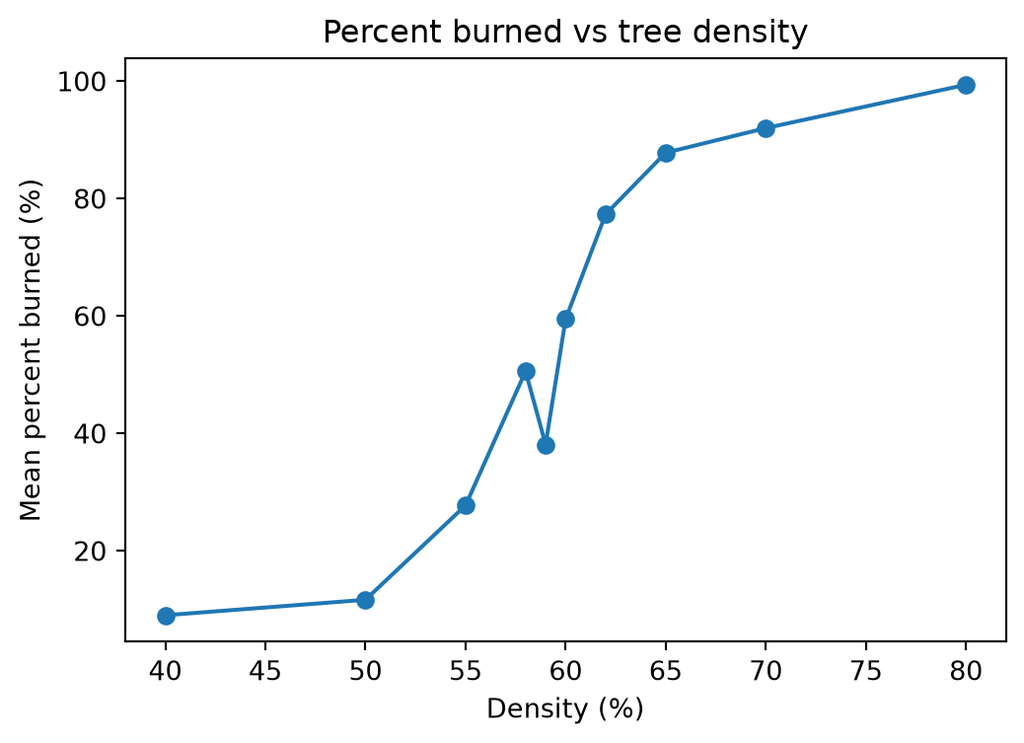

```python
import matplotlib.pyplot as plt

density = [40, 50, 55, 58, 59, 60, 62, 65, 70, 80]
mean_burned = [9.04, 11.67, 27.74, 50.60, 38.11, 59.47, 77.35, 87.82, 92.02, 99.40]  # fill in your means

fig, ax = plt.subplots(figsize=(6, 4))
ax.plot(density, mean_burned, marker="o")
ax.set_xlabel("Density (%)")
ax.set_ylabel("Mean percent burned (%)")
ax.set_title("Percent burned vs tree density")
plt.show()
```

**Figure 2:** Percentage of burned trees for increasing density values

**Task B3 (critical-density estimate).**

From my model, the critical density threshold appears to be 58, although it could be better described in this case as a range from 58-60, similar to the theoretical value of 59. We can see this because the percent burned is “small” at density of 55 (< 30%) and “large” at density of 62 (> 75%). The large dip in percent burned at density of 59 illustrates the variance at the threshold, with only 10 runs the few randomly disconnected networks have dragged down the mean value.

**Task B4 (variability near the threshold).**

The percentage of burned trees at the critical threshold is highly variable and spans a range of low-high percent burned values, compared to 40% and 80% densities which show little variation between runs. This is because at 40% density there are too few linkages between neighbour patches for the fire to spread, and the run finishes quickly, and at 80% density there is such high connection that the majority of the forest burns. Both of these create preditable outcomes. In contrast, at the critical density threshold, many or very few linkages may be created from the random placement, leading to fluctuating outcomes.

## Part C: Summary ODD documentation

Replace each `<...>` placeholder with your own text about the fire model. Keep the **bold** phrases as they are and keep ODD’s key words in *italics*. Aim for one short paragraph per element.

**The overall *purpose* of our model is** to illustrate that a locally ignited fire’s ability to cross a forest flips at a critical tree density, also known as percolation. **Specifically, we are addressing the following questions:** How does the burned area respond to tree density? What is the critical density threshold where the percentage of burned trees is forest-wide? Is this fire spread non-linear in its behaviour (i.e. exhibiting a phase transition)? **To consider our model realistic enough for its purpose, we use the following *patterns*:** a shapr, non-linear threshold (percolation) in fire spread around a critical tree density and a sudden shift from local to forest-wide burning spanning from the left to right edge of the forest.

**The model includes the following *entities*:** Patches representing trees as either present/absent, burning, or burnt. Globals are density, initial trees, and burnt trees. **The *state variables* characterising these entities are listed in Table 1.** **The *spatial* and *temporal* resolution and extent are** a `world size` of 1089 patches (33 patches x 33 patches), one `patch` representing one tree, one `tick` representing one fire spread step to adjacent neighbours, and a run ending when there are no immediate neighbours (N, S, E, W only) for any fire ignition to spread to.

**The most important *processes* of the model, which are repeated every *time step*, are** burning patches ignite neighbouring green patches (North, East, South, West) and then turn into burnt ash.

**The most important *design concepts* of the model are** **Emergence:** where the critical density threshold for a forest-spanning fire emerges from purely local spread rules; and **Stochasticity:** random tree placement only.

**The model is initialized with** each patch becoming a tree with probability equalling `density`, with the entire left column ignited on fire (note that only a present tree will ignite). The `density` slider settings used are a minimum of zero (0) and a maximum of one hundred (100) with increments of one (1) allowed.

**Table 1.** Entities and state variables of the model.

| Entity | Variable | Description | Possible values | Units |
| --- | --- | --- | --- | --- |
| Patch | `pcolor` | Colour representing the state of the patch (i.e. tree present, burned, or absent) | `black` (tree absent), `green` (live tree), `red` (burning tree), `grey` (burnt tree) | Colour code |
| Global | `density` | Probability that any patch will have a tree when initialised | 0 - 100 | Percent |
| Global | `initial trees` | Total number of trees initialised in the world setup | 0 - total number of patches | Count |
| Global | `burned trees` | Total number of trees that have caught fire and burnt | 0 - `initial trees` | Count |